# LYVE1 and REG1B as Biomarkers for Pancreatic Cancer

Exploring potential threshold values in urinary LYVE1 and REG1B levels

Naoise Carolan

# Introduction

Pancreatic Ductal Adenocarcinoma (PDAC) is the most lethal form of cancer, with under 10% of those diagnosed living 5 years after diagnosis. One of the main causes of this extremely high mortality rate is how frequently PDAC goes undetected for long periods of time. PDAC is often asymptotic in its early stages, which makes identifying biomarkers and monitoring these biomarkers in high risk groups critically important. Using a dataset from Debernardi et al 2020 which collected and analyzed urinary samples from 590 patients at multiple hospitals, I analyzed the levels of two potential PDAC biomarkers LYVE1 and REG1B in healthy control group patients, patients with benign pancreatic diseases, and patients with PDAC. I wanted to specifically look at the discrepancies between patients with benign pancreatic diseases and PDAC to better understand how to differentiate between normal levels for patients with pancreatic diseases and levels indicative of PDAC. This data analysis provided useful insight into potential threshold values of both LYVE1 and REG1B.

# LYVE1 Analysis

LYVE1 is a protein primarily used in our lymphatic system that when over expressed promotes the growth of lymphatic vessels, making it easier for tumor cells to metastasize. Due to its association with tumor metastasis, LYVE1 is currently being studied as biomarker for identifying early stage PDAC.

To analyze the urinary levels of LYVE1 in the patients, I opted to use violin plots due to their effectivity in comparing distributions of multiple groups. In order to make the plots more readable, I overlayed the violin plots with box plots to better show the key values. The three diagnosis groups are labeled and differentiated by color for clear distinction between groups, taking into account accessibility needs of those with visual impairments such as color blindness.

# LYVE1 Plot

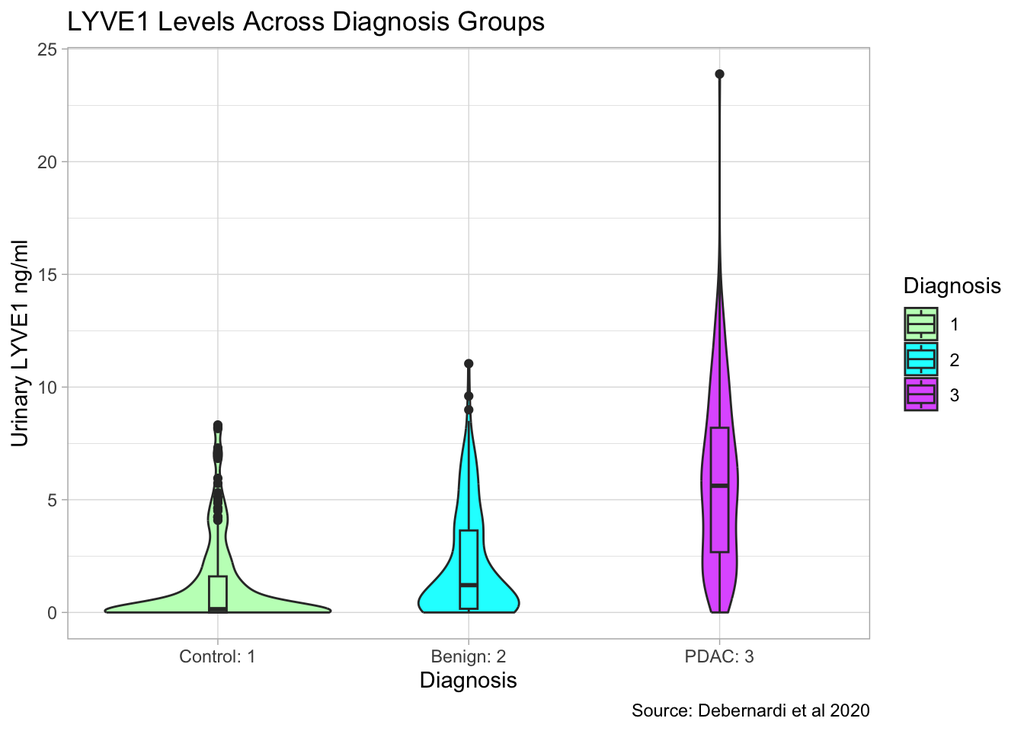

```r
LYVE1Plot = ggplot(data = cancerData, aes(x = diagnosis, y = LYVE1, fill = diagnosis)) + geom_violin() + geom_boxplot(width = 0.07)

LYVE1Plot = LYVE1Plot + scale_fill_manual(breaks = c("1", "2", "3"), values = c("darkseagreen1", "cyan", "mediumorchid1"))

LYVE1Plot = LYVE1Plot + labs(x = "Diagnosis", y = "Urinary LYVE1 ng/ml") + scale_x_discrete(breaks = c("1", "2", "3"), labels = c("Control: 1","Benign: 2","PDAC: 3"))

LYVE1Plot = LYVE1Plot + labs(fill = "Diagnosis", title = "LYVE1 Levels Across Diagnosis Groups", caption = "Source: Debernardi et al 2020") + theme_light()

LYVE1Plot
```

This plot shows a distinct median increase in LYVE1 levels between the control group and benign group, as well as significant jump between the benign group and PDAC group medians. The PDAC group has much larger IQR, while the others, especially control values are tightly clustered, showing a much wider range of normal values for those with PDAC than those without it. The most significant finding that can be observed in this plot stems from the differences in distribution between the benign group and the PDAC group. Although there is overlap between lower LYVE1 levels in the PDAC group and higher LYVE1 levels in the benign group, 75% of patients in the benign group have LYVE1 levels under 3.64 ng/ml, only one patient in the benign group had LYVE1 levels greater than 10 ng/ml, and no patients in the benign group had LYVE1 levels greater than 11.04 ng/ml. This suggests that values above 3.64 ng/ml could be reason to conduct further testing, and values above 10 ng/ml should raise significant concern and always be followed up with further testing.

# REG1B Analysis

REG1B is a protein involved in tissue repair in the pancreas and intestines. People experiencing injuries or inflammation in the pancreas or intestines generally produce greater amounts of REG1B. Because of this, REG1B is being investigated as a potential biomarker for PDAC.

Similarly to the previous plot, I chose to use violin plots to clearly compare distributions of the three diagnosis groups. To make key values clearer, I overlayed the violin plots with box plots. Once again, the three diagnosis groups are labeled and differentiated by color for clear distinction between groups, taking into account accessibility needs of those with visual impairments such as color blindness.

# REG1B Plot

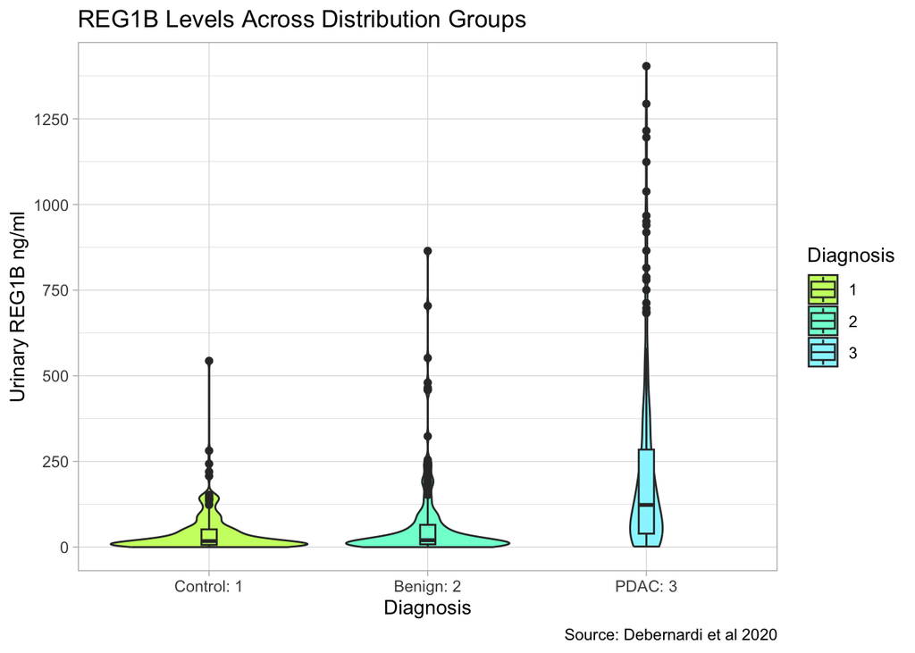

```r
REG1BPlot = ggplot(data = cancerData, aes(x = diagnosis, y = REG1B, fill = diagnosis )) + geom_violin() + geom_boxplot(width = 0.07) + scale_y_continuous(breaks = seq(0, 1500, by = 250))


REG1BPlot = REG1BPlot + scale_fill_manual(breaks = c("1", "2", "3"), values = c("darkolivegreen1", "aquamarine", "cadetblue1"))

REG1BPlot = REG1BPlot + labs(x = "Diagnosis", y = "Urinary REG1B ng/ml") + scale_x_discrete(breaks = c("1", "2", "3"), labels = c("Control: 1","Benign: 2","PDAC: 3"))

REG1BPlot = REG1BPlot + labs(fill = "Diagnosis", title = "REG1B Levels Across Distribution Groups", caption = "Source: Debernardi et al 2020") + theme_light()

REG1BPlot
```

This plot shows almost identical IQRs and similar median values across the control and benign groups, while the PDAC group has an observably larger median and IQR. The control and benign groups have heavily right skewed distributions, with most patients in both groups having extremely low levels of REG1B. In contrast, REG1B levels in the PDAC group are significantly higher, with a median of 123.11 ng/ml as compared to the 17.58 ng/ml median of the control group and the 20.16 ng/ml median of the benign group. The large disparity between the median/IQR for the PDAC group and the median/IQR for the control and benign groups suggests that patients reporting values above 65 ng/ml could benefit from additional testing. Values above 500 ng/ml should raise significant concern and should be followed up with additional testing and patients with these levels should be monitored for increases in REG1B.